# Post-replication citation patterns in psychological science: Preliminary analysis

Hi all,

We’ve now completed all planned data collection and coding for this project. This report contains a preliminary analysis of the data conducted by Tom & Sophia. The study protocol(s) can be found here:

- Original protocol: https://osf.io/eh5qd/
- Amended protocol (we added more up-to-date citation data): https://osf.io/pdvb5/

# Citation count analysis

## Raw citations

Throughout this report, we’ve made larger plots for the Baumeister and Strack cases because their citation counts are substantially larger than the other cases (Sripada, Carter, Caruso).

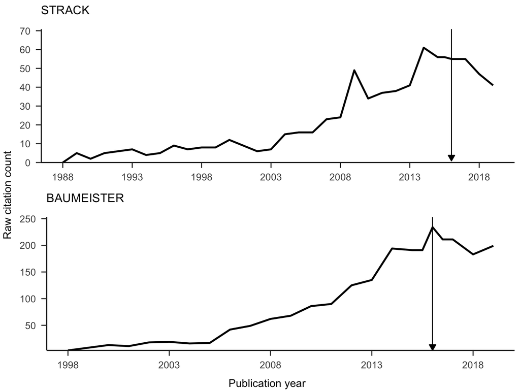

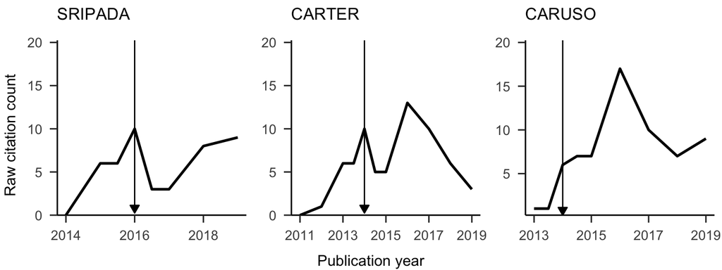

## Standardized citations with reference class

Now we’ll plot standardized citation curves and include citations to the set of reference articles (the dashed grey line). In the graphs below, the annual citation counts for both the target article and reference class are standardized against the calendar year with the highest citation count for the target article (i.e., citations received in that year are set at the standardized value of 100). As defined in the protocol, the reference class in each case is all of the articles published in the same year and in the same journal as the target article. For example, for Baumeister et al. (1998), the reference class is all articles published in 1998 in the Journal of Personality and Social Psychology.

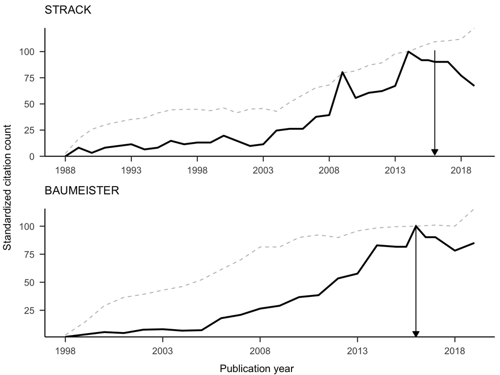

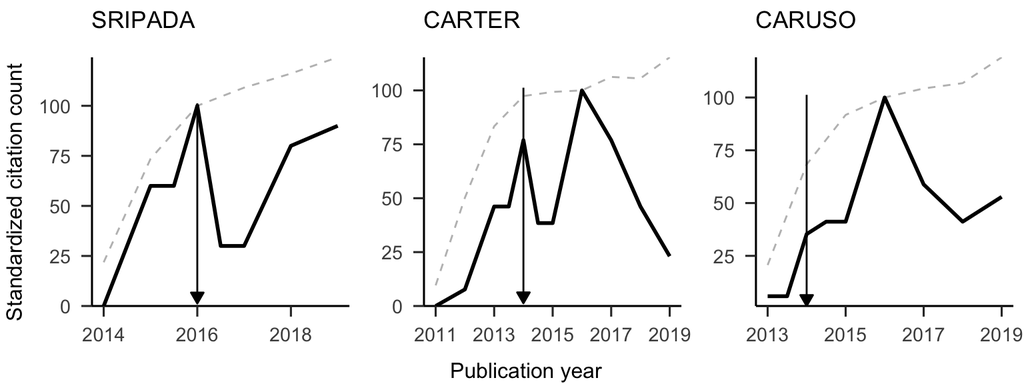

## Issues

# Qualitative assessment of citation content

Across all cases, 98 citing articles had to be excluded because they could not be accessed (n = 90), were non-English language (n = 4), or because the target article was cited in the references but not in the actual text (n = 4). Excluded articles are represented on the graphs below in light grey.

## Claim correction vs. claim perpetuation

One goal of the study was to see if we would observe a post-replication pattern more consistent with “claim correction” or “claim perpetuation”.

A claim correction pattern might involve a decrease in the number of favourable citations reflecting declining field-level endorsement of the original claim. This may be accompanied by an increase in the number of unfavourable citations (an active correction effect) or no change/decline in the number of unfavourable citations (a passive correction effect).

A claim perpetuation pattern might involve an increase or maintain of the number of favourable citations reflecting increasing or maintained field-level endorsement of the original claim. This may be accompanied by an increase in the number of unfavourable citations (a challenged perpetuation effect) or no change/decline in the number of unfavourable citations (an unchallenged perpetuation effect).

To assess this, we classified citations to the target article as favourable, equivocal, unfavourable, or unclassifiable (a general or methodological reference not related to belief in the claim under scruntiny). Each article was coded by two individuals with disagreements resolved through discussion/arbitration. The data shown below represents the agreed upon classifications.

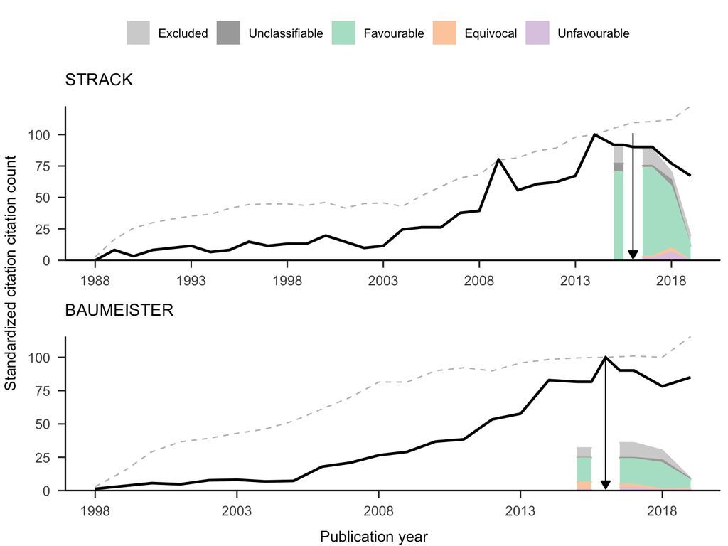

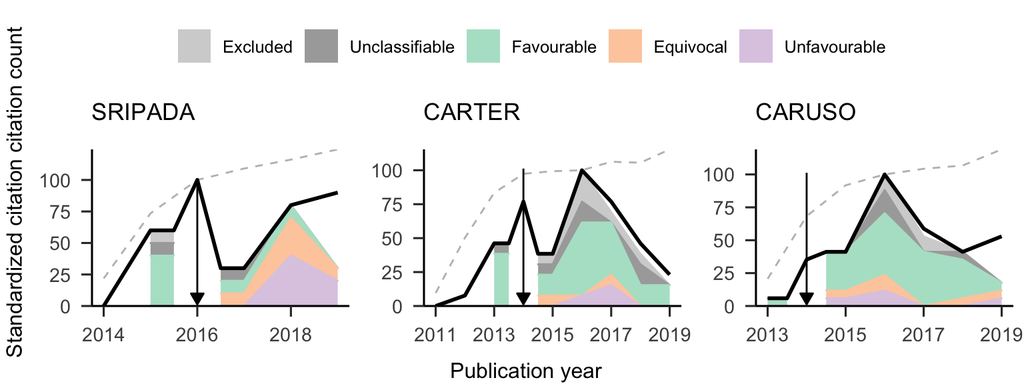

Recall that we only examined 40% of the articles in the Baumeister case which is why there’s a lot of white space.

It may be helpful to zoom in on the relevant part of the timeline too to take a closer look (we’ll just do this for Strack and Baumeister):

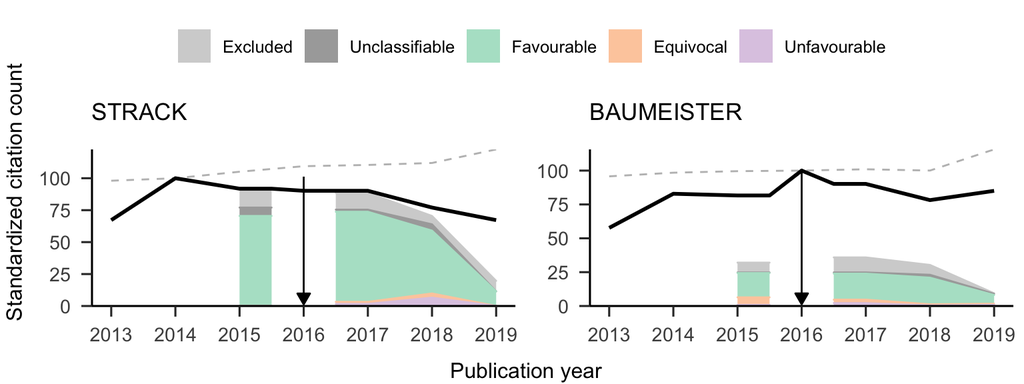

There’s a (to me) surprising preponderance of favourable citations in both cases - consistent with a “claim perpetuation” pattern. This is arguably ‘unchallenged’ because there are very few unfavourable citations. Here are the data in tabular format:

BAUMEISTER

| year | targetCitations | favourable | equivocal | unfavourable | unclassifiable | excluded |
| --- | --- | --- | --- | --- | --- | --- |
| 2015 | 191 | 42 | 13 | 2 | 1 | 17 |
| 2017 | 211 | 45 | 6 | 5 | 2 | 26 |
| 2018 | 183 | 46 | 2 | 1 | 5 | 17 |
| 2019 | 199 | 15 | 2 | 2 | 2 | 1 |

STRACK

| year | targetCitations | favourable | equivocal | unfavourable | unclassifiable | excluded |
| --- | --- | --- | --- | --- | --- | --- |
| 2015 | 56 | 43 | 0 | 0 | 4 | 9 |
| 2017 | 55 | 43 | 1 | 1 | 1 | 8 |
| 2018 | 47 | 30 | 2 | 4 | 3 | 4 |
| 2019 | 41 | 7 | 0 | 0 | 0 | 5 |

SRIPADA

| year | targetCitations | favourable | equivocal | unfavourable | unclassifiable | excluded |
| --- | --- | --- | --- | --- | --- | --- |
| 2015 | 6 | 4 | 0 | 0 | 1 | 1 |
| 2017 | 3 | 1 | 1 | 0 | 1 | 0 |
| 2018 | 8 | 1 | 3 | 4 | 0 | 0 |
| 2019 | 9 | 0 | 1 | 2 | 0 | 0 |

CARTER

| year | targetCitations | favourable | equivocal | unfavourable | unclassifiable | excluded |
| --- | --- | --- | --- | --- | --- | --- |
| 2013 | 6 | 5 | 0 | 0 | 1 | 0 |
| 2015 | 5 | 2 | 1 | 0 | 1 | 1 |
| 2016 | 13 | 7 | 0 | 1 | 2 | 3 |
| 2017 | 10 | 5 | 1 | 2 | 0 | 1 |
| 2018 | 6 | 2 | 0 | 0 | 2 | 1 |
| 2019 | 3 | 2 | 0 | 0 | 0 | 0 |

CARUSO

| year | targetCitations | favourable | equivocal | unfavourable | unclassifiable | excluded |
| --- | --- | --- | --- | --- | --- | --- |
| 2013 | 1 | 1 | 0 | 0 | 0 | 0 |
| 2015 | 7 | 5 | 1 | 1 | 0 | 0 |
| 2016 | 17 | 8 | 2 | 2 | 3 | 2 |
| 2017 | 10 | 7 | 0 | 0 | 0 | 2 |
| 2018 | 7 | 5 | 1 | 0 | 1 | 0 |
| 2019 | 9 | 1 | 1 | 1 | 0 | 0 |

## Citation balance vs. citation bias

We examined whether articles that cite the target study also cite the contradictory replication (a ‘balanced citation effect’) or neglect to do so (a ‘citation bias effect’).

Here we are only looking at articles published in the post-replication period because only they had the opportunity to cite the replication. Recall that this period does not include the year in which the replication was published.

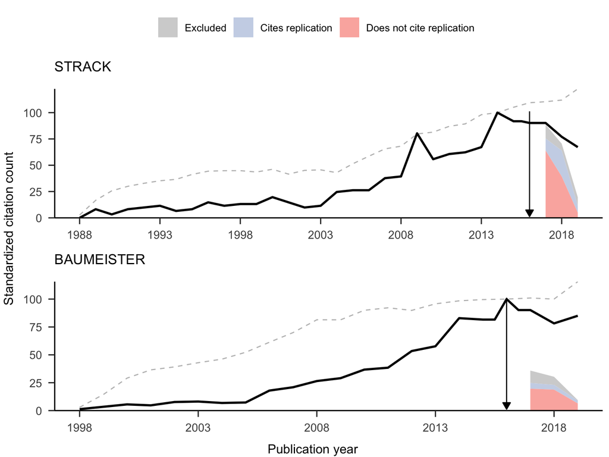

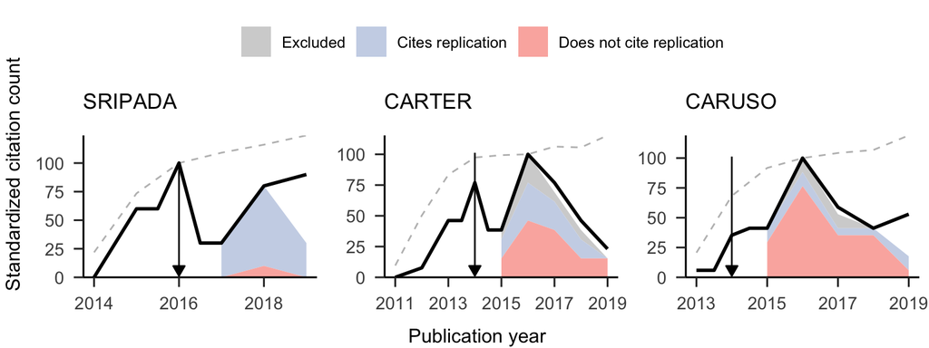

It may be helpful to zoom in on the relevant part of the timeline too to take a closer look (we’ll just do this for Strack and Baumeister):

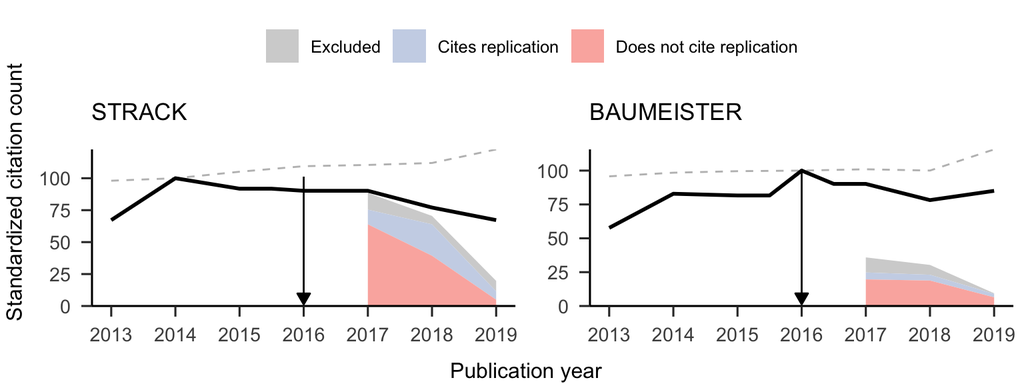

Here’s the data in tabular format:

BAUMEISTER

| year | targetCitations | excluded | replicationCitations | replicationCitations_percent |
| --- | --- | --- | --- | --- |
| 2017 | 211 | 26 | 12 | 6 |
| 2018 | 183 | 17 | 10 | 5 |
| 2019 | 199 | 1 | 6 | 3 |

STRACK

| year | targetCitations | excluded | replicationCitations | replicationCitations_percent |
| --- | --- | --- | --- | --- |
| 2017 | 55 | 8 | 7 | 13 |
| 2018 | 47 | 4 | 15 | 32 |
| 2019 | 41 | 5 | 4 | 10 |

SRIPADA

| year | targetCitations | excluded | replicationCitations | replicationCitations_percent |
| --- | --- | --- | --- | --- |
| 2017 | 3 | 0 | 3 | 100 |
| 2018 | 8 | 0 | 7 | 88 |
| 2019 | 9 | 0 | 3 | 33 |

CARTER

| year | targetCitations | excluded | replicationCitations | replicationCitations_percent |
| --- | --- | --- | --- | --- |
| 2015 | 5 | 1 | 2 | 40 |
| 2016 | 13 | 3 | 4 | 31 |
| 2017 | 10 | 1 | 3 | 30 |
| 2018 | 6 | 1 | 2 | 33 |
| 2019 | 3 | 0 | 0 | 0 |

CARUSO

| year | targetCitations | excluded | replicationCitations | replicationCitations_percent |
| --- | --- | --- | --- | --- |
| 2015 | 7 | 0 | 2 | 29 |
| 2016 | 17 | 2 | 2 | 12 |
| 2017 | 10 | 2 | 1 | 10 |
| 2018 | 7 | 0 | 1 | 14 |
| 2019 | 9 | 0 | 2 | 22 |

And here’s the data summarised at the case level with percentages:

Citations to replication study by articles citing target study in post-replication years

| case | targetCitations | replicationCitations | replicationCitations (%) |
| --- | --- | --- | --- |
| baumeister | 593 | 28 | 5 |
| carter | 37 | 11 | 30 |
| caruso | 50 | 8 | 16 |
| sripada | 20 | 13 | 65 |
| strack | 143 | 26 | 18 |

There seems to be evidence of citation bias (citing the target article but not the replication) in all cases, though the effect is smaller in the Sripada case (probably because this study is probably only well known because of its connection to the Baumeister study - recall that it was used as a methodological proxy for that more influential study in the replication attempt).

## Principled defense vs. hollow defense

Proponents of the original claim may seek to make the case that the contradictory replication actually does not undermine their position. In this case, one might expect counter-arguments that defend the original claim to be presented in articles that cite the replication study and favourably cite the original study.

Here’s the data in tabular format:

Use of counter arguments when target study cited favourably and replication study cited

| case | Replication cited | Counter arguments used | Counter arguments used (%) |
| --- | --- | --- | --- |
| baumeister | 15 | 9 | 60 |
| carter | 3 | 1 | 33 |
| caruso | 1 | 1 | 100 |
| sripada | 1 | 0 | 0 |
| strack | 20 | 10 | 50 |